# STAT 338 Project

Yamini Adusumilli & Matin Akbari

12/14/2021

# Classification Project

## Methods

Prior to building a classification model, I did some exploratory data analysis to get an understanding of the data. I plotted histograms of all of the variables to get assess the distributions and any problems. Given the context of the study, the different types of variables, and potential missing data, I determined that there were no alarming issues about the histograms. The second step was to assess whether there was any missing data and how to handle missing any potential missing data in the training data set. I plotted a chart using the library *naniar* that gave me an overview of how much data was missing in each variable. The histograms and the missing data chart can be found in the appendix. After further analysis, I determined that there was missing data in all the variables other than *id*, *date*, and *location*. It should be noted that the variable *evaporation* was missing 98.78% of data and the variable *sunshine* was missing 98.17% of data. Given the amount of data that was missing in these two variables, I decided to drop them because I believed they would negatively affect the model. Next, I had to handle the missing data for all of the other variables. I decided to use mean imputation for the numerical variables and mode imputation for the categorical variables. After handling the missing data, the data was ready to use for classification. For classification, I decided to use Random Forest from the library *randomForest*. Random Forest is a flexible and supervised machine learning algorithm which can be used for both classification and regression tasks. Supervised learning is when a computer algorithm is trained on input data that has been labeled for a particular output as opposed the unsupervised learning where the the algorithm is presented with unlabeled data and is designed to detect patterns or similarities on its own. As we learned in class, the Random Forest algorithm has an ensemble of decision trees, usually trained with the “bagging” method. The general idea of the bagging method is that a combination of learning models increases the overall result. So, ultimately, the Random Forest algorithm builds multiple decision trees and merges them together to get a more accurate and stable prediction for a given response variable. Prior to using Random Forest, I converted the categorical variables without many levels to factors. Next, I ran the data through random forest using default parameters. After the data went through I calculated the values for the rain_tomorrow column. At first, I calculated 0’s and 1’s because I thought the rain_tomorrow variable was supposed to have binary values like the rain_today column. Doing that, gave me a very high log loss score on Kaggle. Given that the log loss score is supposed to be very low, I tried running the data through Random Forest using different tuning parameters, but was unable to lower the log loss score. So, next, I tried predicting the probabilities of the rain_tomorrow column instead of binary values. I did this using *type = “prob”* in my predict function. Doing this gave me a good log loss score on Kaggle, 0.33223.

## Results

The results of my missing data analysis can be summarized by the chart below.

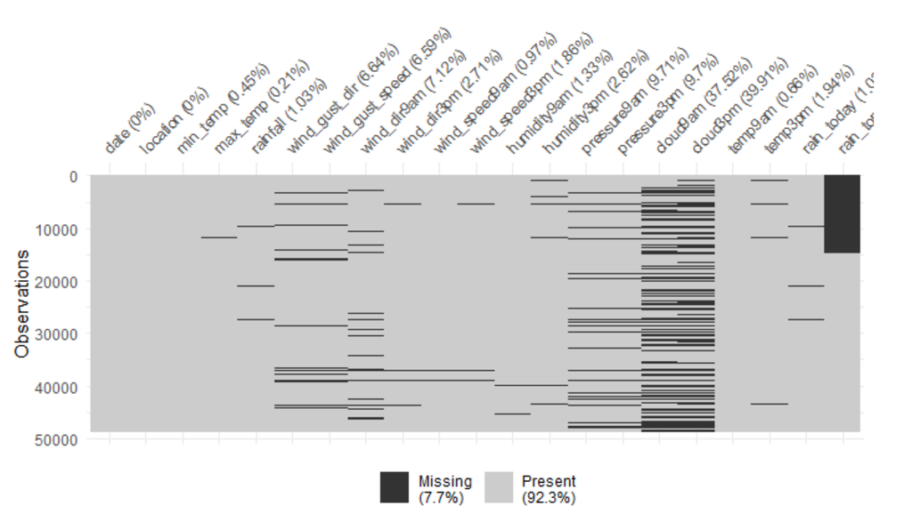

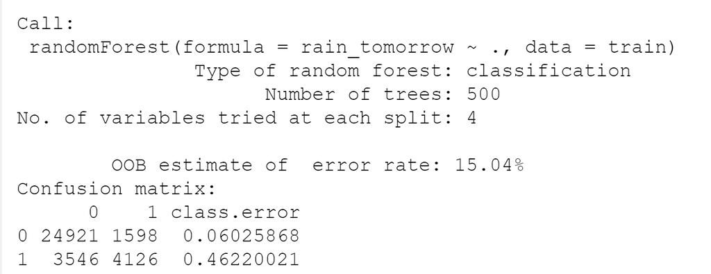

Next, I used the training data to predict the test data and ran my results through Kaggle. The log loss score I received was 0.33223 as seen below.

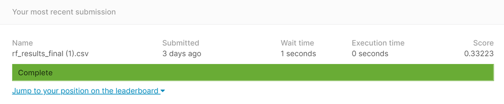

This score is notably lower than the sample_submission.csv score (0.69314) which had probabilities of 0.5 for every observation. So, I determined that the random forest method model appropriately predicted the probabilities of raining the next day in Australia.

## Conclusions/Future work

The overall objective of this project was to use a classification technique to predict the rain_tomorrow column and get a log loss score smaller than the sample_submission score. After doing some research, I decided to use Random Forest as my classification method for this project. However, before I ran the data through Random Forest, I had to do some clean up. First I assessed whether there were any missing data points. Almost all of the variables had missing so I either dropped the variables, used mean imputation, or mode imputation depending on the type of variable and the amount of data missing. I also did some EDA to get an idea of what the data looks like. Then, the data was ready to use. So, I ran it through the random forest algorithm and used my results to predict on the test data. I predicted probabilities for the rain_tomorrow column and ran my results through Kaggle to get a log loss score of 0.33223. If I had more time, I would have liked to test out other models other than Random Forest. In particular, I am interested in what the score would have been if I used Logistic Regression or Support Vector Machines instead. I would also like to repeat this analysis for other countries or cities. Especially places with a lot of rainfall or places with little rainfall to see if the random forest algorithm would predict accurately. I am also interested in doing further analysis about what times of the year Australia sees the most rain. I think it would be very interesting to identify any patterns and make some data visualizations about any trends we see.

## Appendix

Below is the code.

```r
library(naniar)
library(randomForest)
library(caret)
# loading data sets

train = read.csv("train.csv")
test = read.csv("test.csv")
head(train)
```

```
##      id       date      location min_temp max_temp rainfall evaporation
## 1  6364 2010-11-11 BadgerysCreek     16.2     28.9     11.4          NA
## 2  7985 2011-03-09          Sale     14.6     28.3      0.0          NA
## 3  5021 2014-06-06          Nhil      2.6     16.3      0.0          NA
## 4 28546 2017-06-07    Townsville     14.0     25.9      0.0          NA
## 5 42222 2016-12-13         Uluru     16.7     41.7      0.0          NA
## 6 47361 2013-05-23     Nuriootpa      8.5     16.3      6.2          NA
##   sunshine wind_gust_dir wind_gust_speed wind_dir9am wind_dir3pm wind_speed9am
## 1       NA            SW              37           N         NNE             7
## 2       NA           SSE              35         WNW         SSE            11
## 3       NA             S              31           S         SSW             7
## 4       NA           WNW              35         SSW          NE             7
## 5       NA            SW              61         NNE         WSW            26
## 6       NA           ESE              35          SE         SSW            17
##   wind_speed3pm humidity9am humidity3pm pressure9am pressure3pm cloud9am
## 1            15          78          52      1017.2      1011.7       NA
## 2            30          81          65      1012.9      1010.4        7
## 3            20          93          61      1033.1      1031.0       NA
## 4            24          66          37      1020.4      1016.9       NA
## 5            15          17           7      1006.1      1002.6       NA
## 6            13          72          53      1021.8      1021.1        5
##   cloud3pm temp9am temp3pm rain_today rain_tomorrow
## 1       NA    20.3    27.9          1             0
## 2        7    19.0    24.4          0             1
## 3       NA     5.9    14.6          0             0
## 4       NA    20.9    24.7          0             0
## 5       NA    33.2    41.1          0             0
## 6        3    12.2    16.2          1             0
```

```r
head(test)
```

[output not shown]

```r
colnames(train)
```

```
##  [1] "id"              "date"            "location"        "min_temp"
##  [5] "max_temp"        "rainfall"        "evaporation"     "sunshine"
##  [9] "wind_gust_dir"   "wind_gust_speed" "wind_dir9am"     "wind_dir3pm"
## [13] "wind_speed9am"   "wind_speed3pm"   "humidity9am"     "humidity3pm"
## [17] "pressure9am"     "pressure3pm"     "cloud9am"        "cloud3pm"
## [21] "temp9am"         "temp3pm"         "rain_today"      "rain_tomorrow"
```

```r
colnames(test)
```

```
##  [1] "id"              "date"            "location"        "min_temp"
##  [5] "max_temp"        "rainfall"        "evaporation"     "sunshine"
##  [9] "wind_gust_dir"   "wind_gust_speed" "wind_dir9am"     "wind_dir3pm"
## [13] "wind_speed9am"   "wind_speed3pm"   "humidity9am"     "humidity3pm"
## [17] "pressure9am"     "pressure3pm"     "cloud9am"        "cloud3pm"
## [21] "temp9am"         "temp3pm"         "rain_today"
```

```r
dim(train)
```

```
## [1] 34191    24
```

```r
dim(test)
```

```
## [1] 14653    23
```

```r
# checking missing value counts

na_count <-sapply(train, function(y) sum(length(which(is.na(y)))))
na_count <- data.frame(na_count)
na_count
```

```
##                 na_count
## id                     0
## date                   0
## location               0
## min_temp             157
## max_temp              70
## rainfall             357
## evaporation        33775
## sunshine           33566
## wind_gust_dir       2285
## wind_gust_speed     2271
## wind_dir9am         2432
## wind_dir3pm          941
## wind_speed9am        328
## wind_speed3pm        650
## humidity9am          453
## humidity3pm          897
## pressure9am         3381
## pressure3pm         3376
## cloud9am           12886
## cloud3pm           13688
## temp9am              233
## temp3pm              666
## rain_today           357
## rain_tomorrow          0
```

```r
na_count <-sapply(test, function(y) sum(length(which(is.na(y)))))
na_count <- data.frame(na_count)
na_count
```

```
##                 na_count
## id                     0
## date                   0
## location               0
## min_temp              64
## max_temp              32
## rainfall             147
## evaporation        14465
## sunshine           14375
## wind_gust_dir        956
## wind_gust_speed      950
## wind_dir9am         1046
## wind_dir3pm          381
## wind_speed9am        147
## wind_speed3pm        258
## humidity9am          197
## humidity3pm          383
## pressure9am         1364
## pressure3pm         1360
## cloud9am            5441
## cloud3pm            5805
## temp9am               91
## temp3pm              284
## rain_today           147
```

```r
# dropping id because it is a unique identifier
# dropping 'evaporation' because 98.78% values are missing in the train data set
# dropping 'sunshine' because 98.17% values are missing in the train data set

drops <- c("id","evaporation","sunshine")
train <- train[ , !(names(train) %in% drops)]
test <- test[ , !(names(test) %in% drops)]

# adding a rain_tomorrow column to the test data set

test$rain_tomorrow <- NA
```

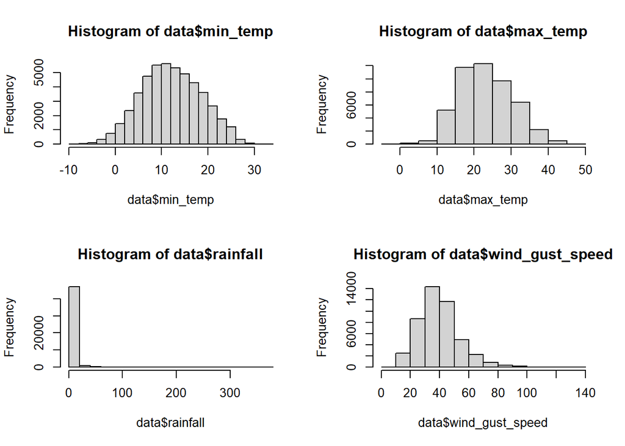

```r
# EDA

# combining train and test for EDA

train2 <- train
data <- rbind(test, train2)

# histograms of all variables

par(mfrow = c(2,2))

hist(data$min_temp)
hist(data$max_temp)
hist(data$rainfall)
hist(data$wind_gust_speed)
```

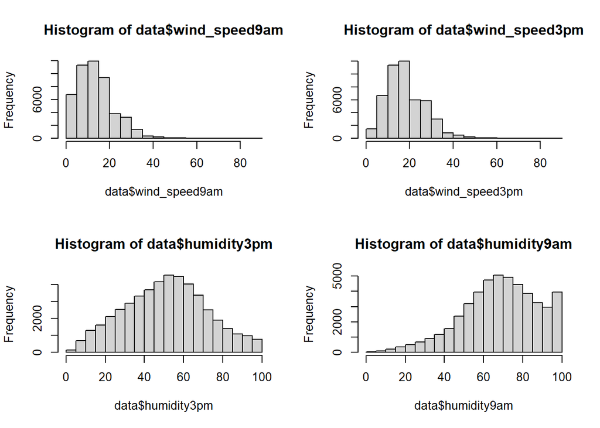

```r
hist(data$wind_speed9am)
hist(data$wind_speed3pm)
hist(data$humidity3pm)
hist(data$humidity9am)
```

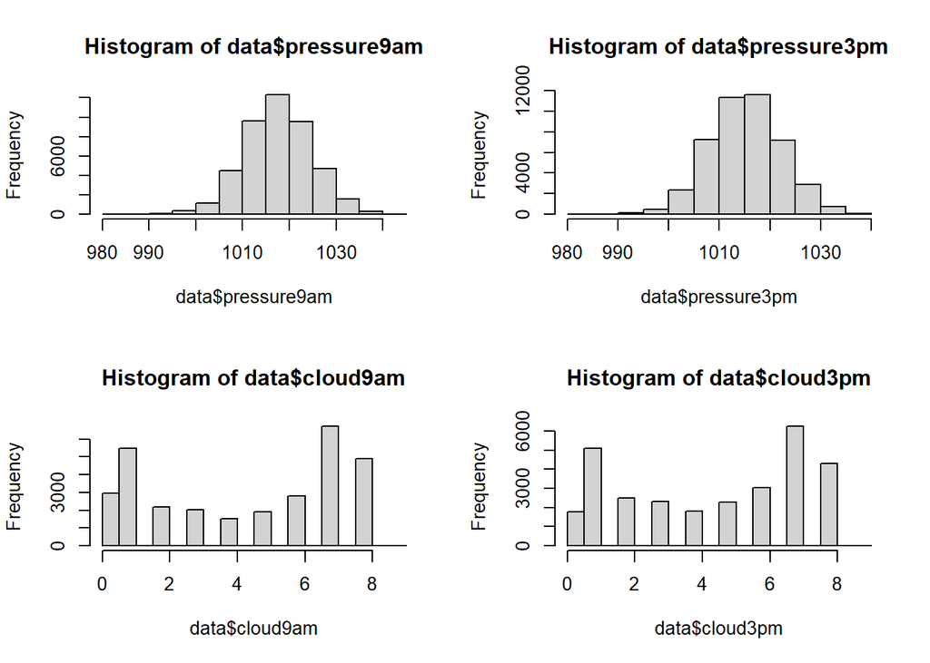

```r
hist(data$pressure9am)
hist(data$pressure3pm)
hist(data$cloud9am)
hist(data$cloud3pm)
```

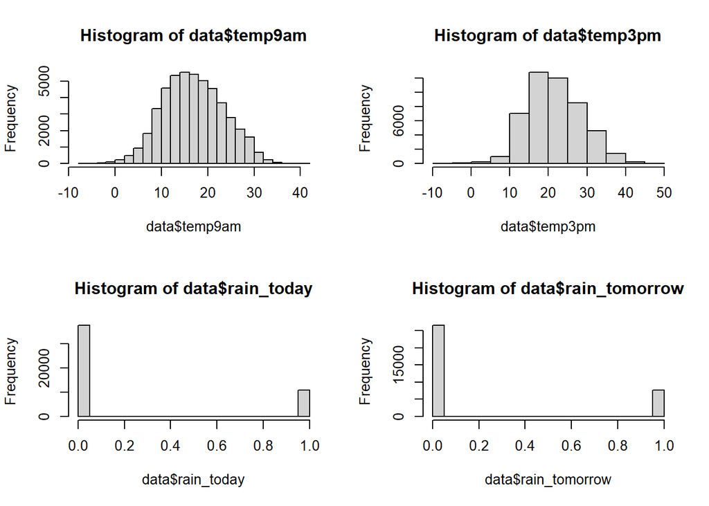

```r
hist(data$temp9am)
hist(data$temp3pm)
hist(data$rain_today)
hist(data$rain_tomorrow)
```

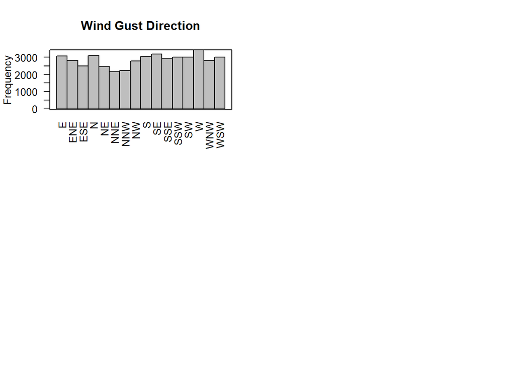

```r
par(oma=c(2,0,0,0))
barplot(table(data$wind_gust_dir), space = 0,
              ylab = "Frequency", main = "Wind Gust Direction",
              border="black", col="grey",las=2)
box()

par(oma=c(2,0,0,0))
```

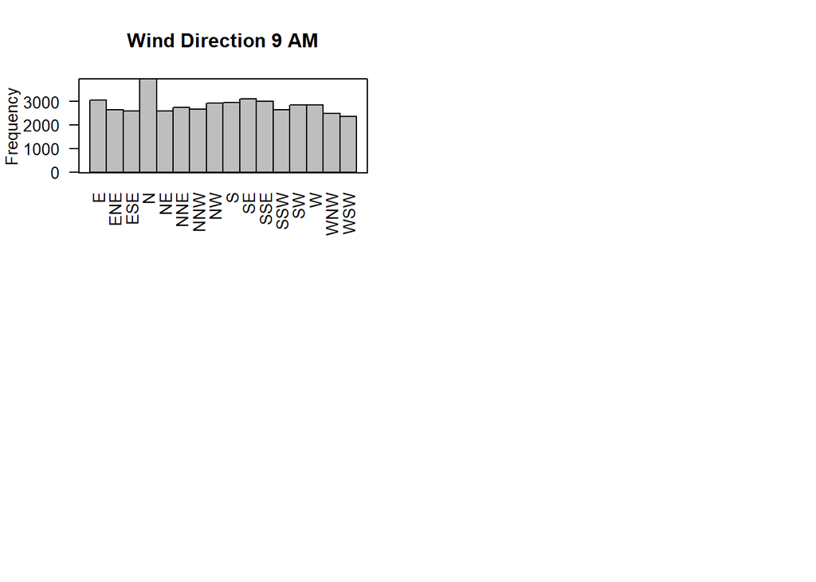

```r
barplot(table(data$wind_dir9am), space = 0,
              ylab = "Frequency", main = "Wind Direction 9 AM",
              border="black", col="grey",las=2)
box()
par(oma=c(2,0,0,0))
```

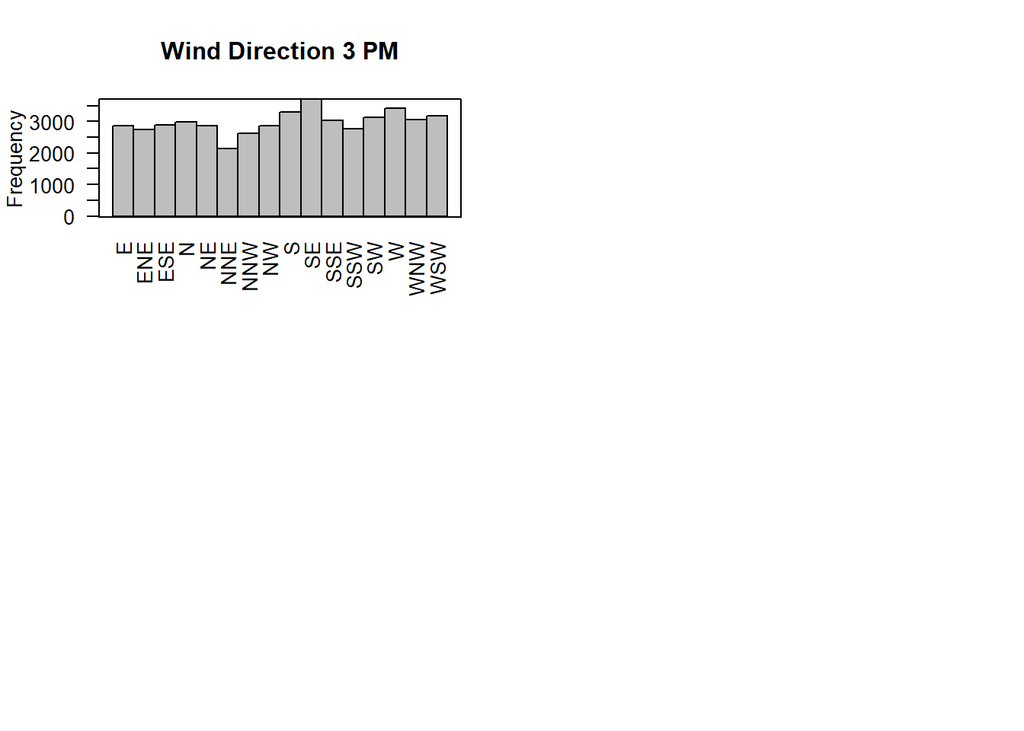

```r
barplot(table(data$wind_dir3pm), space = 0,
              ylab = "Frequency", main = "Wind Direction 3 PM",
              border="black", col="grey",las=2)
box()

par(oma=c(2,0,0,0))
```

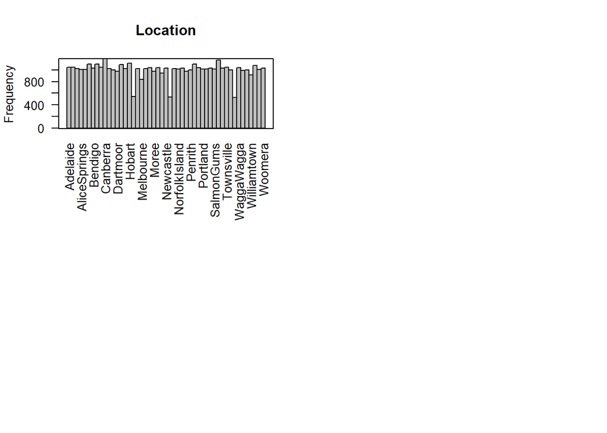

```r
barplot(table(data$location), space = 0,
              ylab = "Frequency", main = "Location",
              border="black", col="grey",las=2)
box()

par(oma=c(2,0,0,0))
```

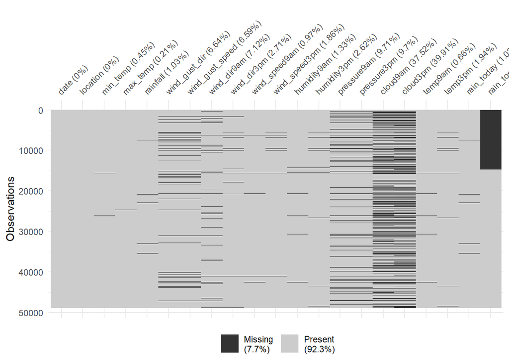

```r
barplot(table(data$date), space = 0,
              ylab = "Frequency", main = "Date",
              border="black", col="grey",las=2)
box()

# visualizing missing data

vis_miss(data, warn_large_data = FALSE)
```

```r
# handling missing values

train$min_temp[is.na(train$min_temp)]<-mean(train$min_temp,na.rm=TRUE)
train$max_temp[is.na(train$max_temp)]<-mean(train$max_temp,na.rm=TRUE)
train$rainfall[is.na(train$rainfall)]<-mean(train$rainfall,na.rm=TRUE)
train$wind_gust_speed[is.na(train$wind_gust_speed)]<-mean(train$wind_gust_speed,na.rm=TRUE)
train$wind_speed9am[is.na(train$wind_speed9am)]<-mean(train$wind_speed9am,na.rm=TRUE)
train$wind_speed3pm[is.na(train$wind_speed3pm)]<-mean(train$wind_speed3pm,na.rm=TRUE)
train$humidity3pm[is.na(train$humidity3pm)]<-mean(train$humidity3pm,na.rm=TRUE)
train$humidity9am[is.na(train$humidity9am)]<-mean(train$humidity9am,na.rm=TRUE)
train$pressure3pm[is.na(train$pressure3pm)]<-mean(train$pressure3pm,na.rm=TRUE)
train$pressure9am[is.na(train$pressure9am)]<-mean(train$pressure9am,na.rm=TRUE)
train$cloud9am[is.na(train$cloud9am)]<-mean(train$cloud9am,na.rm=TRUE)
train$cloud3pm[is.na(train$cloud3pm)]<-mean(train$cloud3pm,na.rm=TRUE)
train$temp9am[is.na(train$temp9am)]<-mean(train$temp9am,na.rm=TRUE)
train$temp3pm[is.na(train$temp3pm)]<-mean(train$temp3pm,na.rm=TRUE)

table(train$wind_gust_dir)
```

```
##
##    E  ENE  ESE    N   NE  NNE  NNW   NW    S   SE  SSE  SSW   SW    W  WNW  WSW
## 2147 1988 1747 2174 1739 1524 1551 1923 2110 2235 2056 2111 2079 2456 1965 2101
```

```r
train$wind_gust_dir[is.na(train$wind_gust_dir)]<-"W"
table(train$wind_dir3pm)
```

```
##
##    E  ENE  ESE    N   NE  NNE  NNW   NW    S   SE  SSE  SSW   SW    W  WNW  WSW
## 2012 1920 1999 2056 2005 1487 1829 2000 2323 2604 2127 1915 2200 2404 2124 2245
```

```r
train$wind_dir3pm[is.na(train$wind_dir3pm)]<-"SE"
table(train$wind_dir9am)
```

```
##
##    E  ENE  ESE    N   NE  NNE  NNW   NW    S   SE  SSE  SSW   SW    W  WNW  WSW
## 2172 1864 1767 2785 1808 1902 1872 2052 2089 2150 2122 1831 1970 1980 1743 1652
```

```r
train$wind_dir9am[is.na(train$wind_dir9am)]<-"N"
table(train$rain_today)
```

```
##
##     0     1
## 26203  7631
```

```r
train$rain_today[is.na(train$rain_today)]<-0

test$min_temp[is.na(test$min_temp)]<-mean(test$min_temp,na.rm=TRUE)
test$max_temp[is.na(test$max_temp)]<-mean(test$max_temp,na.rm=TRUE)
test$rainfall[is.na(test$rainfall)]<-mean(test$rainfall,na.rm=TRUE)
test$wind_gust_speed[is.na(test$wind_gust_speed)]<-mean(test$wind_gust_speed,na.rm=TRUE)
test$wind_speed9am[is.na(test$wind_speed9am)]<-mean(test$wind_speed9am,na.rm=TRUE)
test$wind_speed3pm[is.na(test$wind_speed3pm)]<-mean(test$wind_speed3pm,na.rm=TRUE)
test$humidity3pm[is.na(test$humidity3pm)]<-mean(test$humidity3pm,na.rm=TRUE)
test$humidity9am[is.na(test$humidity9am)]<-mean(test$humidity9am,na.rm=TRUE)
test$pressure3pm[is.na(test$pressure3pm)]<-mean(test$pressure3pm,na.rm=TRUE)
test$pressure9am[is.na(test$pressure9am)]<-mean(test$pressure9am,na.rm=TRUE)
test$cloud9am[is.na(test$cloud9am)]<-mean(test$cloud9am,na.rm=TRUE)
test$cloud3pm[is.na(test$cloud3pm)]<-mean(test$cloud3pm,na.rm=TRUE)
test$temp9am[is.na(test$temp9am)]<-mean(test$temp9am,na.rm=TRUE)
test$temp3pm[is.na(test$temp3pm)]<-mean(test$temp3pm,na.rm=TRUE)

table(test$wind_gust_dir)
```

```
##
##   E ENE ESE   N  NE NNE NNW  NW   S  SE SSE SSW  SW   W WNW WSW
## 934 811 747 934 729 668 684 865 940 944 892 902 923 973 838 913
```

```r
test$wind_gust_dir[is.na(test$wind_gust_dir)]<-"W"
table(test$wind_dir3pm)
```

```
##
##    E  ENE  ESE    N   NE  NNE  NNW   NW    S   SE  SSE  SSW   SW    W  WNW  WSW
##  846  811  889  930  861  658  789  852  982 1098  904  846  937 1007  938  924
```

```r
test$wind_dir3pm[is.na(test$wind_dir3pm)]<-"SE"
table(test$wind_dir9am)
```

```
##
##    E  ENE  ESE    N   NE  NNE  NNW   NW    S   SE  SSE  SSW   SW    W  WNW  WSW
##  875  765  830 1166  788  832  806  872  865  947  869  806  879  874  737  696
```

```r
test$wind_dir9am[is.na(test$wind_dir9am)]<-"N"
table(test$rain_today)
```

```
##
##     0     1
## 11297  3209
```

```r
test$rain_today[is.na(test$rain_today)]<-0
```

```r
# fitting random forest

train = as.data.frame(train)
train$wind_gust_dir = factor(train$wind_gust_dir)
train$wind_dir3pm = factor(train$wind_dir3pm)
train$wind_dir9am = factor(train$wind_dir9am)
train$rain_today = factor(train$rain_today)
train$rain_tomorrow = factor(train$rain_tomorrow)

test = as.data.frame(test)
test$wind_gust_dir = factor(test$wind_gust_dir)
test$wind_dir3pm = factor(test$wind_dir3pm)
test$wind_dir9am = factor(test$wind_dir9am)
test$rain_today = factor(test$rain_today)
test$rain_tomorrow = factor(test$rain_tomorrow)

rf <- randomForest(rain_tomorrow~., data=train)
print(rf)
```

```
##
## Call:
##  randomForest(formula = rain_tomorrow ~ ., data = train)
##                Type of random forest: classification
##                      Number of trees: 500
## No. of variables tried at each split: 4
##
##         OOB estimate of  error rate: 15.03%
## Confusion matrix:
##       0    1 class.error
## 0 24931 1588  0.05988159
## 1  3552 4120  0.46298227
```

```r
# predicting probabilities

rf_pred <- predict(rf, test, type = "prob")

results = as.data.frame(rf_pred)

write.csv(results,"rf_results_final.csv", row.names = TRUE)

# kaggle score: 0.33223
```